# Homework 2

# Part 1: 911 Calls Project

For this part you will be analyzing some 911 call data from [Kaggle](https://www.kaggle.com/mchirico/montcoalert). The data contains the following fields:

- lat : String variable, Latitude
- lng: String variable, Longitude
- desc: String variable, Description of the Emergency Call
- zip: String variable, Zipcode
- title: String variable, Title
- timeStamp: String variable, YYYY-MM-DD HH:MM:SS
- twp: String variable, Township
- addr: String variable, Address
- e: String variable, Dummy variable (always 1)

Just go along with this notebook and try to complete the instructions or answer the questions using your Python and Data Science skills!

## Data and Setup

**Import numpy and pandas**

```python
import numpy as np
import pandas as pd
```

**Import visualization libraries and set %matplotlib inline.**

```python
import matplotlib.pyplot as plt
import seaborn as sns
%matplotlib inline
```

**Read in the csv file as a dataframe called df**

```python
df = pd.read_csv('911.csv')
```

**Check the info() of the df**

```python
df.info()
```

```
<class 'pandas.core.frame.DataFrame'>
RangeIndex: 99492 entries, 0 to 99491
Data columns (total 9 columns):
lat          99492 non-null float64
lng          99492 non-null float64
desc         99492 non-null object
zip          86637 non-null float64
title        99492 non-null object
timeStamp    99492 non-null object
twp          99449 non-null object
addr         98973 non-null object
e            99492 non-null int64
dtypes: float64(3), int64(1), object(5)
memory usage: 6.8+ MB
```

**Check the head of df**

```python
df.head()
```

|  | lat | lng | desc | zip | title | timeStamp | twp | addr | e |
| --- | --- | --- | --- | --- | --- | --- | --- | --- | --- |
| 0 | 40.297876 | -75.581294 | REINDEER CT & DEAD END; NEW HANOVER; Station ... | 19525.0 | EMS: BACK PAINS/INJURY | 2015-12-10 17:40:00 | NEW HANOVER | REINDEER CT & DEAD END | 1 |
| 1 | 40.258061 | -75.264680 | BRIAR PATH & WHITEMARSH LN; HATFIELD TOWNSHIP... | 19446.0 | EMS: DIABETIC EMERGENCY | 2015-12-10 17:40:00 | HATFIELD TOWNSHIP | BRIAR PATH & WHITEMARSH LN | 1 |
| 2 | 40.121182 | -75.351975 | HAWS AVE; NORRISTOWN; 2015-12-10 @ 14:39:21-St... | 19401.0 | Fire: GAS-ODOR/LEAK | 2015-12-10 17:40:00 | NORRISTOWN | HAWS AVE | 1 |
| 3 | 40.116153 | -75.343513 | AIRY ST & SWEDE ST; NORRISTOWN; Station 308A;... | 19401.0 | EMS: CARDIAC EMERGENCY | 2015-12-10 17:40:01 | NORRISTOWN | AIRY ST & SWEDE ST | 1 |
| 4 | 40.251492 | -75.603350 | CHERRYWOOD CT & DEAD END; LOWER POTTSGROVE; S... | NaN | EMS: DIZZINESS | 2015-12-10 17:40:01 | LOWER POTTSGROVE | CHERRYWOOD CT & DEAD END | 1 |

## Basic Questions

```python
df['zip'].head()
```

```
0    19525.0
1    19446.0
2    19401.0
3    19401.0
4        NaN
Name: zip, dtype: float64
```

```python
df['twp'].head()
```

```
0          NEW HANOVER
1    HATFIELD TOWNSHIP
2           NORRISTOWN
3           NORRISTOWN
4     LOWER POTTSGROVE
Name: twp, dtype: object
```

**Take a look at the 'title' column, how many unique title codes are there?**

```python
df['title'].nunique()
```

```
110
```

## Creating new features

**In the titles column there are "Reasons/Departments" specified before the title code. These are EMS, Fire, and Traffic. Create a new column called "Reason" that contains this string value.**

**For example, if the title column value is EMS: BACK PAINS/INJURY , the Reason column value would be EMS.**

```python
df['Reason'] = df['title'].apply(lambda title: title.split(':')[0])
df.head()
```

|  | lat | lng | desc | zip | title | timeStamp | twp | addr | e | Reason |
| --- | --- | --- | --- | --- | --- | --- | --- | --- | --- | --- |
| 0 | 40.297876 | -75.581294 | REINDEER CT & DEAD END; NEW HANOVER; Station ... | 19525.0 | EMS: BACK PAINS/INJURY | 2015-12-10 17:40:00 | NEW HANOVER | REINDEER CT & DEAD END | 1 | EMS |
| 1 | 40.258061 | -75.264680 | BRIAR PATH & WHITEMARSH LN; HATFIELD TOWNSHIP... | 19446.0 | EMS: DIABETIC EMERGENCY | 2015-12-10 17:40:00 | HATFIELD TOWNSHIP | BRIAR PATH & WHITEMARSH LN | 1 | EMS |
| 2 | 40.121182 | -75.351975 | HAWS AVE; NORRISTOWN; 2015-12-10 @ 14:39:21-St... | 19401.0 | Fire: GAS-ODOR/LEAK | 2015-12-10 17:40:00 | NORRISTOWN | HAWS AVE | 1 | Fire |
| 3 | 40.116153 | -75.343513 | AIRY ST & SWEDE ST; NORRISTOWN; Station 308A;... | 19401.0 | EMS: CARDIAC EMERGENCY | 2015-12-10 17:40:01 | NORRISTOWN | AIRY ST & SWEDE ST | 1 | EMS |
| 4 | 40.251492 | -75.603350 | CHERRYWOOD CT & DEAD END; LOWER POTTSGROVE; S... | NaN | EMS: DIZZINESS | 2015-12-10 17:40:01 | LOWER POTTSGROVE | CHERRYWOOD CT & DEAD END | 1 | EMS |

**What is the most common Reason for a 911 call based off of this new column?**

```python
df['Reason'].value_counts()
```

```
EMS        48877
Traffic    35695
Fire       14920
Name: Reason, dtype: int64
```

**Now use seaborn to create a countplot of 911 calls by Reason.**

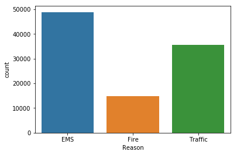

```python
sns.countplot('Reason', data = df)
```

**Now let us begin to focus on time information. What is the data type of the objects in the timeStamp column?**

```python
type(df['timeStamp'].iloc[0])
```

```
str
```

**You should have seen that these timestamps are still strings. Use [pd.to_datetime](http://pandas.pydata.org/pandas-docs/stable/generated/pandas.to_datetime.html) to convert the column from strings to DateTime objects.**

```python
df['timeStamp'] = pd.to_datetime(df['timeStamp'])
df.head()
```

|  | lat | lng | desc | zip | title | timeStamp | twp | addr | e | Reason |
| --- | --- | --- | --- | --- | --- | --- | --- | --- | --- | --- |
| 0 | 40.297876 | -75.581294 | REINDEER CT & DEAD END; NEW HANOVER; Station ... | 19525.0 | EMS: BACK PAINS/INJURY | 2015-12-10 17:40:00 | NEW HANOVER | REINDEER CT & DEAD END | 1 | EMS |
| 1 | 40.258061 | -75.264680 | BRIAR PATH & WHITEMARSH LN; HATFIELD TOWNSHIP... | 19446.0 | EMS: DIABETIC EMERGENCY | 2015-12-10 17:40:00 | HATFIELD TOWNSHIP | BRIAR PATH & WHITEMARSH LN | 1 | EMS |
| 2 | 40.121182 | -75.351975 | HAWS AVE; NORRISTOWN; 2015-12-10 @ 14:39:21-St... | 19401.0 | Fire: GAS-ODOR/LEAK | 2015-12-10 17:40:00 | NORRISTOWN | HAWS AVE | 1 | Fire |
| 3 | 40.116153 | -75.343513 | AIRY ST & SWEDE ST; NORRISTOWN; Station 308A;... | 19401.0 | EMS: CARDIAC EMERGENCY | 2015-12-10 17:40:01 | NORRISTOWN | AIRY ST & SWEDE ST | 1 | EMS |
| 4 | 40.251492 | -75.603350 | CHERRYWOOD CT & DEAD END; LOWER POTTSGROVE; S... | NaN | EMS: DIZZINESS | 2015-12-10 17:40:01 | LOWER POTTSGROVE | CHERRYWOOD CT & DEAD END | 1 | EMS |

**You can now grab specific attributes from a Datetime object by calling them. For example:**

```
time = df['timeStamp'].iloc[0]
time.hour
```

**Now that the timestamp column are actually DateTime objects, use .apply() to create 3 new columns called Hour, Month, and Day of Week. You will create these columns based on the timeStamp column.**

```python
df['Hour'] = df['timeStamp'].apply(lambda time: time.hour)
df['Month'] = df['timeStamp'].apply(lambda time: time.month)
df['Day of Week'] = df['timeStamp'].apply(lambda time: time.dayofweek)
df.head()
```

|  | lat | lng | desc | zip | title | timeStamp | twp | addr | e | Reason | Hour | Month | Day of Week |
| --- | --- | --- | --- | --- | --- | --- | --- | --- | --- | --- | --- | --- | --- |
| 0 | 40.297876 | -75.581294 | REINDEER CT & DEAD END; NEW HANOVER; Station ... | 19525.0 | EMS: BACK PAINS/INJURY | 2015-12-10 17:40:00 | NEW HANOVER | REINDEER CT & DEAD END | 1 | EMS | 17 | 12 | 3 |
| 1 | 40.258061 | -75.264680 | BRIAR PATH & WHITEMARSH LN; HATFIELD TOWNSHIP... | 19446.0 | EMS: DIABETIC EMERGENCY | 2015-12-10 17:40:00 | HATFIELD TOWNSHIP | BRIAR PATH & WHITEMARSH LN | 1 | EMS | 17 | 12 | 3 |
| 2 | 40.121182 | -75.351975 | HAWS AVE; NORRISTOWN; 2015-12-10 @ 14:39:21-St... | 19401.0 | Fire: GAS-ODOR/LEAK | 2015-12-10 17:40:00 | NORRISTOWN | HAWS AVE | 1 | Fire | 17 | 12 | 3 |
| 3 | 40.116153 | -75.343513 | AIRY ST & SWEDE ST; NORRISTOWN; Station 308A;... | 19401.0 | EMS: CARDIAC EMERGENCY | 2015-12-10 17:40:01 | NORRISTOWN | AIRY ST & SWEDE ST | 1 | EMS | 17 | 12 | 3 |
| 4 | 40.251492 | -75.603350 | CHERRYWOOD CT & DEAD END; LOWER POTTSGROVE; S... | NaN | EMS: DIZZINESS | 2015-12-10 17:40:01 | LOWER POTTSGROVE | CHERRYWOOD CT & DEAD END | 1 | EMS | 17 | 12 | 3 |

**Notice how the Day of Week is an integer 0-6. Use the .map() with this dictionary to map the actual string names to the day of the week:**

```
dmap = {0:'Mon',1:'Tue',2:'Wed',3:'Thu',4:'Fri',5:'Sat',6:'Sun'}
```

```python
dmap = {0:'Mon',1:'Tue',2:'Wed',3:'Thu',4:'Fri',5:'Sat',6:'Sun'}
```

**Now create a countplot of the Day of Week column with the hue based on the Reason column.**

```python
df['Day of Week'] = df['Day of Week'].map(dmap)
df.head()
```

|  | lat | lng | desc | zip | title | timeStamp | twp | addr | e | Reason | Hour | Month | Day of Week |
| --- | --- | --- | --- | --- | --- | --- | --- | --- | --- | --- | --- | --- | --- |
| 0 | 40.297876 | -75.581294 | REINDEER CT & DEAD END; NEW HANOVER; Station ... | 19525.0 | EMS: BACK PAINS/INJURY | 2015-12-10 17:40:00 | NEW HANOVER | REINDEER CT & DEAD END | 1 | EMS | 17 | 12 | Thu |
| 1 | 40.258061 | -75.264680 | BRIAR PATH & WHITEMARSH LN; HATFIELD TOWNSHIP... | 19446.0 | EMS: DIABETIC EMERGENCY | 2015-12-10 17:40:00 | HATFIELD TOWNSHIP | BRIAR PATH & WHITEMARSH LN | 1 | EMS | 17 | 12 | Thu |
| 2 | 40.121182 | -75.351975 | HAWS AVE; NORRISTOWN; 2015-12-10 @ 14:39:21-St... | 19401.0 | Fire: GAS-ODOR/LEAK | 2015-12-10 17:40:00 | NORRISTOWN | HAWS AVE | 1 | Fire | 17 | 12 | Thu |
| 3 | 40.116153 | -75.343513 | AIRY ST & SWEDE ST; NORRISTOWN; Station 308A;... | 19401.0 | EMS: CARDIAC EMERGENCY | 2015-12-10 17:40:01 | NORRISTOWN | AIRY ST & SWEDE ST | 1 | EMS | 17 | 12 | Thu |
| 4 | 40.251492 | -75.603350 | CHERRYWOOD CT & DEAD END; LOWER POTTSGROVE; S... | NaN | EMS: DIZZINESS | 2015-12-10 17:40:01 | LOWER POTTSGROVE | CHERRYWOOD CT & DEAD END | 1 | EMS | 17 | 12 | Thu |

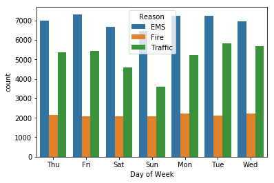

```python
sns.countplot(x='Day of Week',data=df,hue='Reason')
```

**Now do the same for Month:**

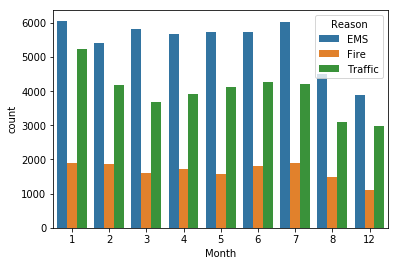

```python
sns.countplot(x='Month',data=df,hue='Reason')
```

**Did you notice something strange about the Plot?**

**You should have noticed it was missing some Months, let's see if we can maybe fill in this information by plotting the information in another way, possibly a simple line plot that fills in the missing months, in order to do this, we'll need to do some work with pandas...**

```python
permonth = df.groupby('Month').count()
permonth
```

| Month | lat | lng | desc | zip | title | timeStamp | twp | addr | e | Reason | Hour | Day of Week |
| --- | --- | --- | --- | --- | --- | --- | --- | --- | --- | --- | --- | --- |
| 1 | 13205 | 13205 | 13205 | 11527 | 13205 | 13205 | 13203 | 13096 | 13205 | 13205 | 13205 | 13205 |
| 2 | 11467 | 11467 | 11467 | 9930 | 11467 | 11467 | 11465 | 11396 | 11467 | 11467 | 11467 | 11467 |
| 3 | 11101 | 11101 | 11101 | 9755 | 11101 | 11101 | 11092 | 11059 | 11101 | 11101 | 11101 | 11101 |
| 4 | 11326 | 11326 | 11326 | 9895 | 11326 | 11326 | 11323 | 11283 | 11326 | 11326 | 11326 | 11326 |
| 5 | 11423 | 11423 | 11423 | 9946 | 11423 | 11423 | 11420 | 11378 | 11423 | 11423 | 11423 | 11423 |
| 6 | 11786 | 11786 | 11786 | 10212 | 11786 | 11786 | 11777 | 11732 | 11786 | 11786 | 11786 | 11786 |
| 7 | 12137 | 12137 | 12137 | 10633 | 12137 | 12137 | 12133 | 12088 | 12137 | 12137 | 12137 | 12137 |
| 8 | 9078 | 9078 | 9078 | 7832 | 9078 | 9078 | 9073 | 9025 | 9078 | 9078 | 9078 | 9078 |
| 12 | 7969 | 7969 | 7969 | 6907 | 7969 | 7969 | 7963 | 7916 | 7969 | 7969 | 7969 | 7969 |

**Now see if you can create a linear fit on the number of calls per month.**

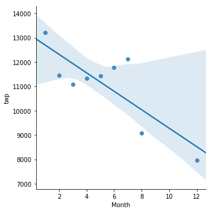

```python
sns.lmplot(x='Month',y='twp',data=permonth.reset_index())
```

**Create a new column called 'Date' that contains the date from the timeStamp column.**

```python
df['Date']=df['timeStamp'].apply(lambda t: t.date())
df.head()
```

|  | lat | lng | desc | zip | title | timeStamp | twp | addr | e | Reason | Hour | Month | Day of Week | Date |
| --- | --- | --- | --- | --- | --- | --- | --- | --- | --- | --- | --- | --- | --- | --- |
| 0 | 40.297876 | -75.581294 | REINDEER CT & DEAD END; NEW HANOVER; Station ... | 19525.0 | EMS: BACK PAINS/INJURY | 2015-12-10 17:40:00 | NEW HANOVER | REINDEER CT & DEAD END | 1 | EMS | 17 | 12 | Thu | 2015-12-10 |
| 1 | 40.258061 | -75.264680 | BRIAR PATH & WHITEMARSH LN; HATFIELD TOWNSHIP... | 19446.0 | EMS: DIABETIC EMERGENCY | 2015-12-10 17:40:00 | HATFIELD TOWNSHIP | BRIAR PATH & WHITEMARSH LN | 1 | EMS | 17 | 12 | Thu | 2015-12-10 |
| 2 | 40.121182 | -75.351975 | HAWS AVE; NORRISTOWN; 2015-12-10 @ 14:39:21-St... | 19401.0 | Fire: GAS-ODOR/LEAK | 2015-12-10 17:40:00 | NORRISTOWN | HAWS AVE | 1 | Fire | 17 | 12 | Thu | 2015-12-10 |
| 3 | 40.116153 | -75.343513 | AIRY ST & SWEDE ST; NORRISTOWN; Station 308A;... | 19401.0 | EMS: CARDIAC EMERGENCY | 2015-12-10 17:40:01 | NORRISTOWN | AIRY ST & SWEDE ST | 1 | EMS | 17 | 12 | Thu | 2015-12-10 |
| 4 | 40.251492 | -75.603350 | CHERRYWOOD CT & DEAD END; LOWER POTTSGROVE; S... | NaN | EMS: DIZZINESS | 2015-12-10 17:40:01 | LOWER POTTSGROVE | CHERRYWOOD CT & DEAD END | 1 | EMS | 17 | 12 | Thu | 2015-12-10 |

**Now create a plot of counts of 911 calls per date.**

```python
perdate = df.groupby('Date').count()
perdate.head()
```

| Date | lat | lng | desc | zip | title | timeStamp | twp | addr | e | Reason | Hour | Month | Day of Week |
| --- | --- | --- | --- | --- | --- | --- | --- | --- | --- | --- | --- | --- | --- |
| 2015-12-10 | 115 | 115 | 115 | 100 | 115 | 115 | 115 | 113 | 115 | 115 | 115 | 115 | 115 |
| 2015-12-11 | 396 | 396 | 396 | 333 | 396 | 396 | 395 | 391 | 396 | 396 | 396 | 396 | 396 |
| 2015-12-12 | 403 | 403 | 403 | 333 | 403 | 403 | 403 | 401 | 403 | 403 | 403 | 403 | 403 |
| 2015-12-13 | 319 | 319 | 319 | 280 | 319 | 319 | 319 | 317 | 319 | 319 | 319 | 319 | 319 |
| 2015-12-14 | 447 | 447 | 447 | 387 | 447 | 447 | 446 | 445 | 447 | 447 | 447 | 447 | 447 |

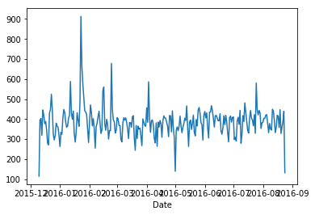

```python
df.groupby('Date').count()['twp'].plot()
```

**Now recreate this plot but create 3 separate plots with each plot representing a Reason for the 911 call**

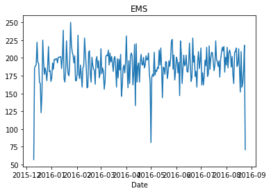

```python
df[df['Reason']=='EMS'].groupby('Date').count()['twp'].plot()
plt.title('EMS')
plt.show()
```

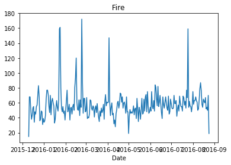

```python
df[df['Reason']=='Fire'].groupby('Date').count()['twp'].plot()
plt.title('Fire')
plt.show()
```

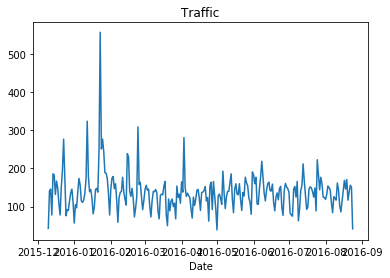

```python
df[df['Reason']=='Traffic'].groupby('Date').count()['twp'].plot()
plt.title('Traffic')
plt.show()
```

# Part 2: Finance Data Project

In this part you'll focus on exploratory data analysis of stock prices. We'll focus on bank stocks and see how they progressed throughout the financial criss all the way to early 2016.

## Get the Data

**To use pandas to directly read data from Yahoo finance, you'll need to install pandas-datareader library. Install the library by going to your terminal or command prompt and typing:**

conda install pandas-datareader

First you need to start with the proper imports, which I've already laid out for you here.

### The Imports

Already filled out for you.

```python
import pandas_datareader.data as web
import pandas as pd
import numpy as np
import datetime
%matplotlib inline
```

## Data

We need to get data using pandas datareader. We will get stock information for the following banks:

- Bank of America
- CitiGroup
- Goldman Sachs
- JPMorgan Chase
- Morgan Stanley
- Wells Fargo

**Figure out how to get the stock data from Jan 1st 2006 to Jan 1st 2016 for each of these banks. Set the six banks to be included in a dataframe, with the variable name for that bank being its ticker symbol. This will involve a few steps:**

1. Use datetime to set start and end datetime objects.
2. Figure out the ticker symbol for each bank.
3. Figure out how to use datareader to grab info on the stock.

**Use Yahoo finance as a source, for example:**

```
# Bank of America
BAC = web.DataReader("BAC", 'yahoo', start, end)
```

```python
start = datetime.datetime(2006,1,1)
end = datetime.datetime(2016,1,1)
BAC = web.DataReader("BAC", 'yahoo', start, end)
C = web.DataReader("C", 'yahoo', start, end)
GS = web.DataReader("GS", 'yahoo', start, end)
JPM = web.DataReader("JPM", 'yahoo', start, end)
MS = web.DataReader("MS", 'yahoo', start, end)
WF = web.DataReader("WF", 'yahoo', start, end)
```

```python
tickers = ["BAC","C","GS","JPM","MS","WF"]
```

**Investigate the data. What kind of variables are avaiable?**

```python
stocks = pd.concat([BAC,C,GS,JPM,MS,WF],keys=tickers,axis=1)
stocks.columns.names = ['Ticker','Info']
```

```python
stocks.head()
```

| Ticker Info Date | BAC High | BAC Low | BAC Open | BAC Close | BAC Volume | BAC Adj Close | C High | C Low | C Open | C Close | ... | MS Open | MS Close | MS Volume | MS Adj Close | WF High | WF Low | WF Open | WF Close | WF Volume | WF Adj Close |
| --- | --- | --- | --- | --- | --- | --- | --- | --- | --- | --- | --- | --- | --- | --- | --- | --- | --- | --- | --- | --- | --- |
| 2006-01-03 | 47.180000 | 46.150002 | 46.919998 | 47.080002 | 16296700.0 | 36.147552 | 493.799988 | 481.100006 | 490.000000 | 492.899994 | ... | 57.169998 | 58.310001 | 5377000.0 | 38.834549 | 73.766388 | 72.228844 | 72.705597 | 72.884392 | 23400.0 | 58.224358 |
| 2006-01-04 | 47.240002 | 46.450001 | 47.000000 | 46.580002 | 17757900.0 | 35.763645 | 491.000000 | 483.500000 | 488.600006 | 483.799988 | ... | 58.700001 | 58.349998 | 7977800.0 | 38.861198 | 74.719902 | 72.884392 | 73.122757 | 74.016678 | 27300.0 | 59.128895 |
| 2006-01-05 | 46.830002 | 46.320000 | 46.580002 | 46.639999 | 14970700.0 | 35.809727 | 487.799988 | 484.000000 | 484.399994 | 486.200012 | ... | 58.549999 | 58.509998 | 5778000.0 | 38.967754 | 73.420738 | 72.526817 | 73.003578 | 72.669853 | 11100.0 | 58.052967 |
| 2006-01-06 | 46.910000 | 46.349998 | 46.799999 | 46.570000 | 12599800.0 | 35.755962 | 489.000000 | 482.000000 | 488.799988 | 486.200012 | ... | 58.770000 | 58.570000 | 6889800.0 | 39.007713 | 76.769974 | 73.897499 | 73.897499 | 75.744926 | 34800.0 | 60.509514 |
| 2006-01-09 | 46.970001 | 46.360001 | 46.720001 | 46.599998 | 15619400.0 | 35.779007 | 487.399994 | 483.000000 | 486.000000 | 483.899994 | ... | 58.630001 | 59.189999 | 4144500.0 | 39.420616 | 75.268181 | 74.195473 | 74.493439 | 74.195473 | 31000.0 | 59.271729 |

5 rows × 36 columns

Let's explore the data a bit!

**What is the max Close price for each bank's stock throughout the time period?**

```python
stocks.xs(key='Close',axis=1, level='Info').max()
```

```
Ticker
BAC     54.900002
C      564.099976
GS     247.919998
JPM     70.080002
MS      89.300003
WF      99.868889
dtype: float64
```

**Create a new empty DataFrame called returns. This dataframe will contain the returns for each bank's stock. returns are typically defined by:**

$$r_t = \frac{p_t - p_{t-1}}{p_{t-1}} = \frac{p_t}{p_{t-1}} - 1$$

```python
returns = pd.DataFrame()
for bank in tickers:
    returns[bank + "return"] = stocks[bank]["Close"].pct_change()
returns.head()
```

| Date | BACreturn | Creturn | GSreturn | JPMreturn | MSreturn | WFreturn |
| --- | --- | --- | --- | --- | --- | --- |
| 2006-01-03 | NaN | NaN | NaN | NaN | NaN | NaN |
| 2006-01-04 | -0.010620 | -0.018462 | -0.013812 | -0.014183 | 0.000686 | 0.015535 |
| 2006-01-05 | 0.001288 | 0.004961 | -0.000393 | 0.003029 | 0.002742 | -0.018196 |
| 2006-01-06 | -0.001501 | 0.000000 | 0.014169 | 0.007046 | 0.001025 | 0.042316 |
| 2006-01-09 | 0.000644 | -0.004731 | 0.012030 | 0.016242 | 0.010586 | -0.020456 |

**Create a pairplot using seaborn of the returns dataframe. Is there any stock which stands out to you? If so, can you figure out why?**

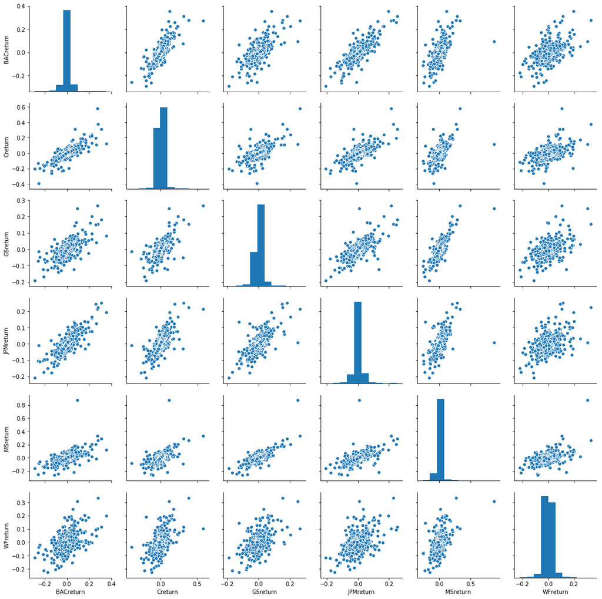

```python
sns.pairplot(returns.dropna())
```

**Using this returns DataFrame, figure out on what dates each bank stock had the best and worst single day returns. Do you notice anything special?**

```python
returns.idxmin(axis = 0)
```

```
BACreturn   2009-01-20
Creturn     2009-02-27
GSreturn    2009-01-20
JPMreturn   2009-01-20
MSreturn    2008-10-09
WFreturn    2008-09-29
dtype: datetime64[ns]
```

```python
returns.idxmax(axis = 0)
```

```
BACreturn   2009-04-09
Creturn     2008-11-24
GSreturn    2008-11-24
JPMreturn   2009-01-21
MSreturn    2008-10-13
WFreturn    2009-03-10
dtype: datetime64[ns]
```

**Create a distplot of the 2015 returns for Morgan Stanley**

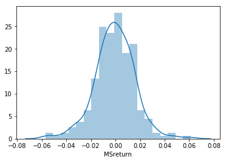

```python
sns.distplot(returns.loc['2015-01-01':'2015-12-31']['MSreturn'].dropna())
```

**Create a distplot of the 2008 returns for CitiGroup**

```python
sns.distplot(returns.loc['2008-01-01':'2008-12-31']['Creturn'].dropna())
```

[output not shown]

**Create a line plot showing Close price for each bank for the entire index of time.**

```python
stocks.xs(key='Close',axis=1,level='Info').plot()
```

[output not shown]

Let's analyze the moving averages for these stocks in the year 2008.

**Plot the rolling 30 day average against the Close Price for Bank Of America's stock for the year 2008**

```python
BAC['Close'].loc['2008-01-01':'2008-12-31'].rolling(window=30).mean().plot(label="30 day average")
BAC['Close'].loc['2008-01-01':'2009-01-01'].plot(label="BAC Close")
plt.legend()
```

[output not shown]